# Gex

I have linearity, but a pattern in my graph. There are some outliers in the TA. These three outliers are all in the Content 7 in Treatment C. Let’s see, what happens, if I take them out.

```r
#select(ca, TA$) %>% droplevels
ca1<- filter(ca, TA<750) %>% droplevels()
summary(ca1)
```

```
##     Content   Treatment   ppm       nut           Ex           Light
##  Unkn-01: 3   A:9       high:15   high:18   Min.   :1687   Min.   :143.2
##  Unkn-02: 3   B:9       low :18   low :15   1st Qu.:1842   1st Qu.:148.1
##  Unkn-03: 3   C:6                           Median :2081   Median :165.9
##  Unkn-04: 3   D:9                           Mean   :2016   Mean   :164.9
##  Unkn-05: 3                                 3rd Qu.:2162   3rd Qu.:178.4
##  Unkn-06: 3                                 Max.   :2263   Max.   :190.3
##  (Other):15
##       Temp           Sal              pH              TA
##  Min.   :25.8   Min.   :35.20   Min.   :7.300   Min.   :360.0
##  1st Qu.:25.8   1st Qu.:35.30   1st Qu.:7.300   1st Qu.:425.0
##  Median :25.8   Median :35.50   Median :7.700   Median :430.0
##  Mean   :25.8   Mean   :35.47   Mean   :7.518   Mean   :430.5
##  3rd Qu.:25.8   3rd Qu.:35.70   3rd Qu.:7.700   3rd Qu.:460.0
##  Max.   :25.8   Max.   :35.80   Max.   :7.700   Max.   :465.0
##
##       NO3             PO43
##  Min.   :2.583   Min.   :0.1170
##  1st Qu.:5.273   1st Qu.:0.1350
##  Median :6.873   Median :0.4680
##  Mean   :6.417   Mean   :0.4076
##  3rd Qu.:7.727   3rd Qu.:0.6250
##  Max.   :9.834   Max.   :0.7430
##
```

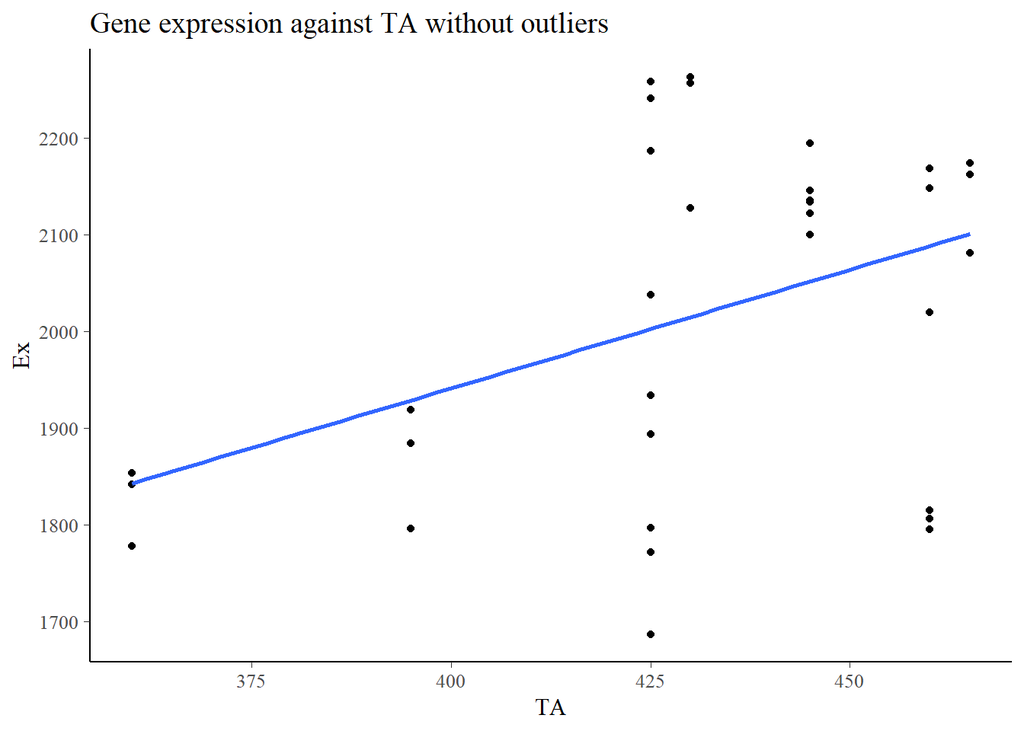

```r
ggplot(ca1, aes(y=Ex, x=TA)) +
  geom_point() +
  geom_smooth(method='lm', se=FALSE) +
         ggtitle("Gene expression against TA without outliers")
```

**Result** : Looks good without the outliers. Maybe I switch my analysis to ca1 instead.

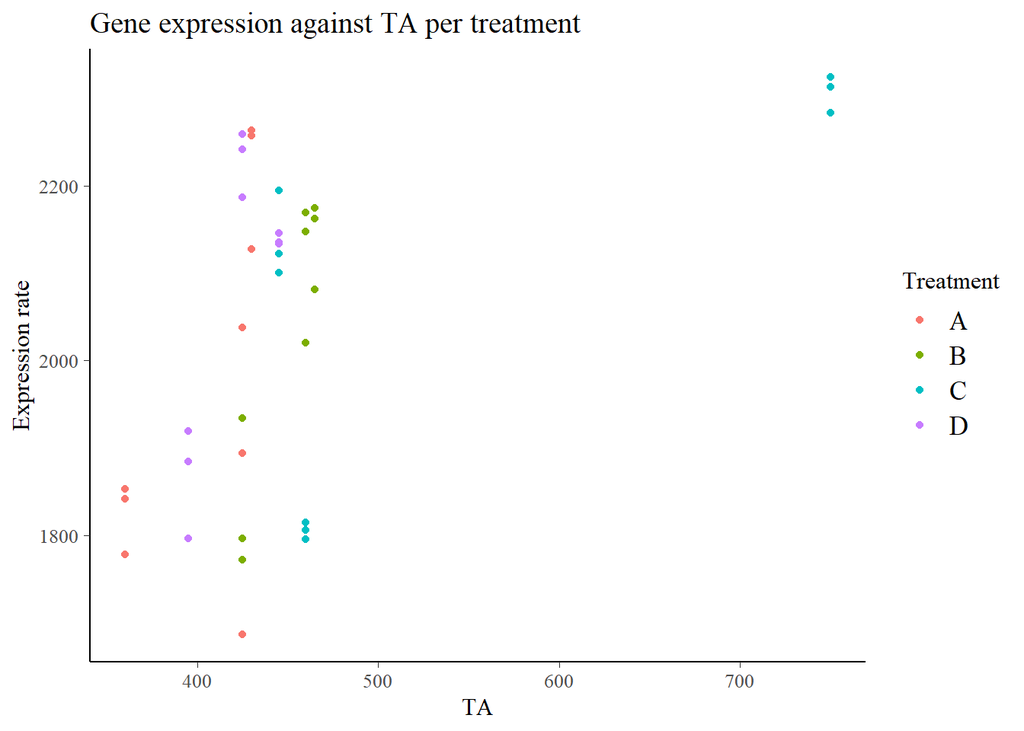

```r
ggplot(ca, aes(x=TA, y=Ex, group=Treatment, color=Treatment)) +
  geom_point(aes(x=TA,y=Ex, group=Treatment, color=Treatment)) +
       ggtitle("Gene expression against TA per treatment") +
    scale_y_continuous(name="Expression rate")
```

```r
#Ex<-table(unlist(ca))
# barplot(Ex, xlab="Sample", ylab="Expression rate", col=gray(12:0/12))
# this plot doesn't make sense really... and doesn't work neither...
```

### Assumption 1: Individuals are independent:

For this I need to use scatterplotMatrix, right? And then have a look, if some variables are connected, i.e. the slope is impacted by another variable.

### Assumption 2: Variance is homogeneous:

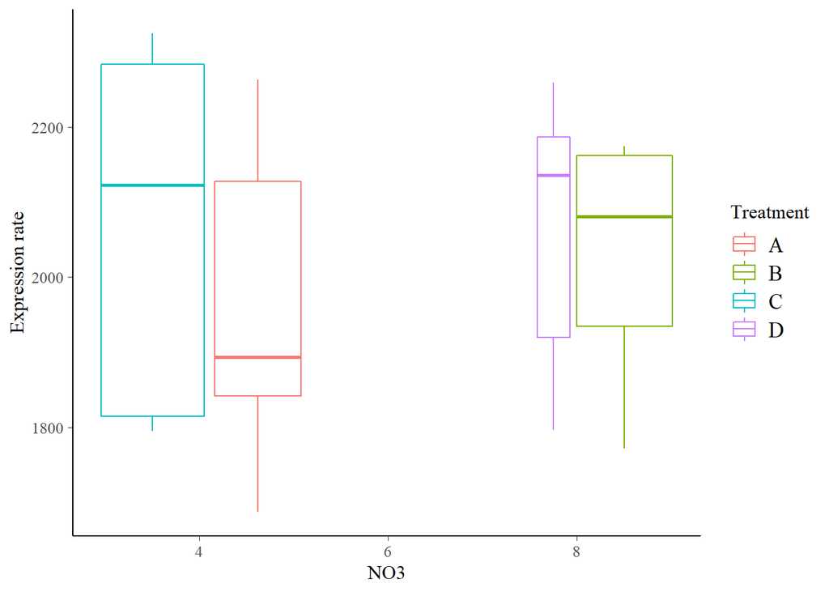

```r
ggplot(ca, aes(y=Ex, x=NO3, colour=Treatment)) +
        geom_boxplot()+
    scale_y_continuous(name="Expression rate")
```

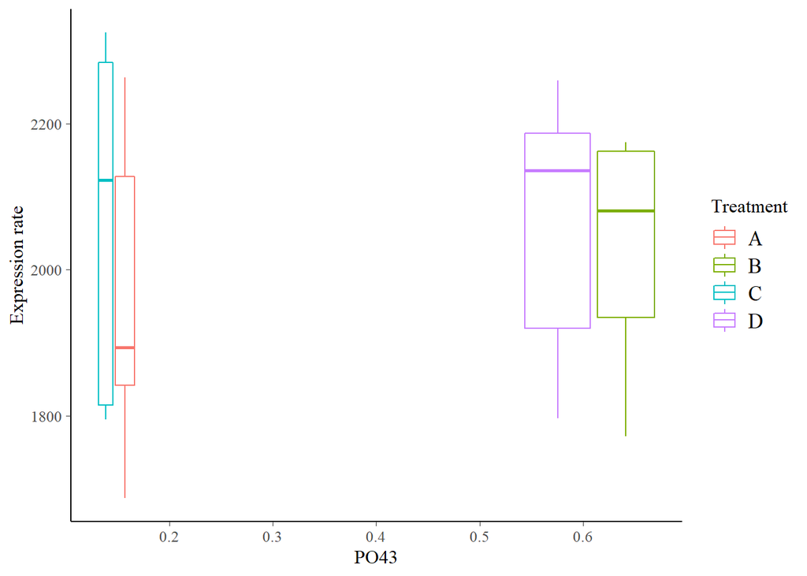

```r
ggplot(ca, aes(y=Ex, x=PO43, colour=Treatment)) +
        geom_boxplot()+
    scale_y_continuous(name="Expression rate")
```

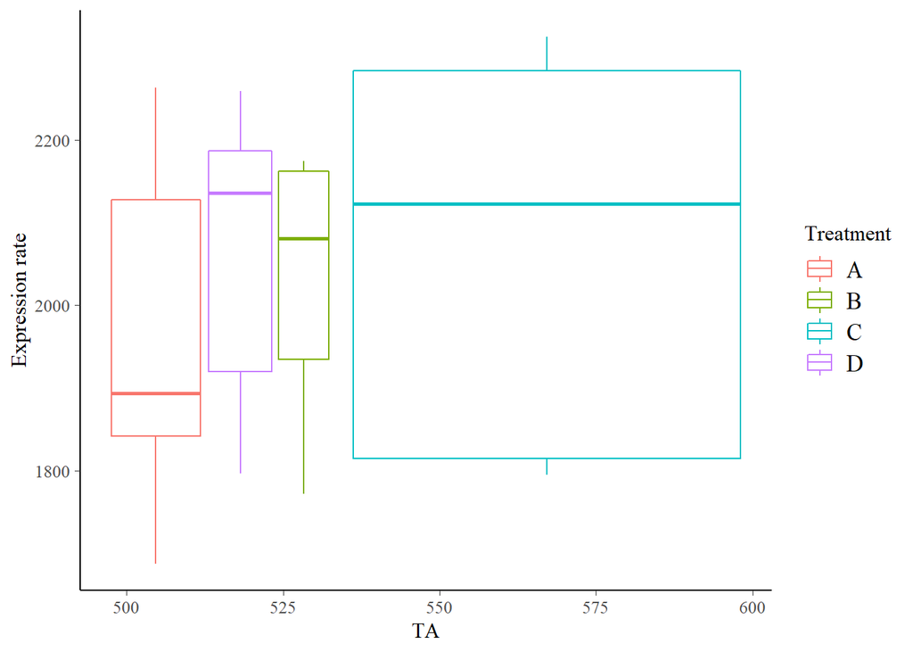

```r
ggplot(ca, aes(y=Ex, x=TA, colour=Treatment)) +
        geom_boxplot() +
    scale_y_continuous(name="Expression rate")
```

**Result** : Due to the shape of the boxplot, there is no relation between mean and variance visible and my variance is homogeneous.

What I can also see in these boxplots is that in treatment A, which is the control, for both nutrients and TA, the mean is low and for all other treatments, it’s high.

### Assumption 3: Residuals follow a normal distribution:

Let’s check on normality using a **Normal QQ-Plot**, which is implemented in the **autoplot function**. I need to fit a lm first though.

I try to fit a **linear model** first, even though I expect a lm should not be plausible:

```r
ca.lm<-lm(Ex~Treatment, data=ca)
summary(ca.lm)
```

```
##
## Call:
## lm(formula = Ex ~ Treatment, data = ca)
##
## Residuals:
##     Min      1Q  Median      3Q     Max
## -288.45 -167.15   54.16  141.71  291.99
##
## Coefficients:
##             Estimate Std. Error t value Pr(>|t|)
## (Intercept)  1971.14      63.87  30.862   <2e-16 ***
## TreatmentB     57.45      90.33   0.636    0.529
## TreatmentC    112.68      90.33   1.248    0.221
## TreatmentD    106.86      90.33   1.183    0.246
## ---
## Signif. codes:  0 '***' 0.001 '**' 0.01 '*' 0.05 '.' 0.1 ' ' 1
##
## Residual standard error: 191.6 on 32 degrees of freedom
## Multiple R-squared:  0.05934,    Adjusted R-squared:  -0.02884
## F-statistic: 0.6729 on 3 and 32 DF,  p-value: 0.575
```

**Result** : No significance between the treatments.

### Validate lm

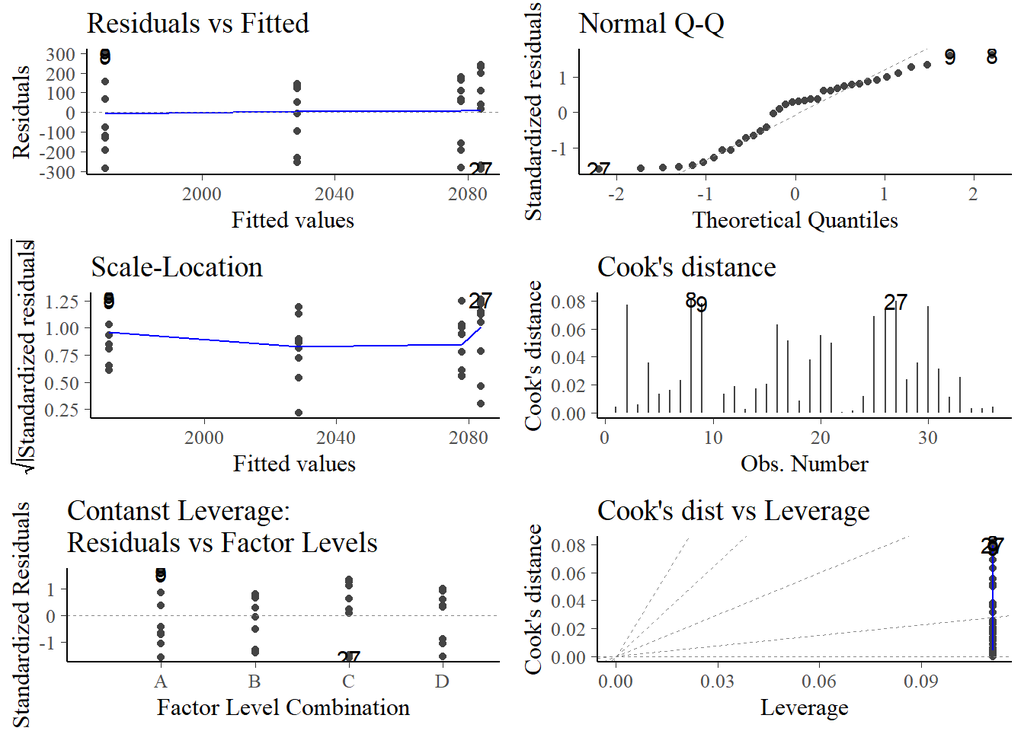

```r
autoplot(ca.lm, which=1:6)
```

**Result** : Cook’s D is fine, but the pattern in the residuals and the tail in the Normal Q-Q- Plot hints towards non normality in my data.

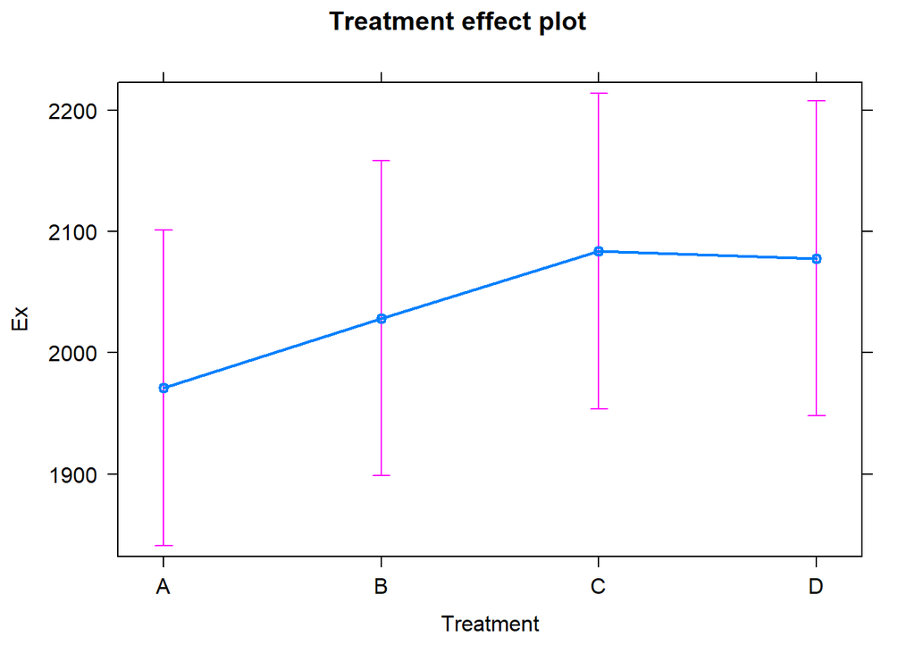

```r
plot(allEffects(ca.lm))
```

Is this a **good fit** anyways?

```r
ca.resid=sum(resid(ca.lm, type='pearson')^2)
1-pchisq(ca.resid,ca.lm$df.residual)
```

```
## [1] 0
```

**Result** : Since the p-value is not greater than 0.05, but 0, we reject. it’s a lack of fit. Only when getting a value of greater than 0.05, we are good.

check for **dispersion**

To calculate the value of dispersion (var/mu), which should be 1, we take the residuals of the model and divide them by the df.

```r
ca.resid/ca.lm$df.residual
```

```
## [1] 36714.31
```

**Result** : My model is 36,000 times **overdispersed**. When the observed variance is higher than the variance of a theoretical model, overdispersion has occurred. We took the residuals from original dataset devided by residuals of used model: this is the dispersion, which should be close to 1, which it is not, so it’s overdispersed. WHY? Maybe due to excessive zeros>

Just to make sure, check on zeros:

```r
summary(ca)
```

```
##     Content   Treatment   ppm       nut           Ex           Light
##  Unkn-01: 3   A:9       high:18   high:18   Min.   :1687   Min.   :143.2
##  Unkn-02: 3   B:9       low :18   low :18   1st Qu.:1851   1st Qu.:152.2
##  Unkn-03: 3   C:9                           Median :2111   Median :166.4
##  Unkn-04: 3   D:9                           Mean   :2040   Mean   :165.4
##  Unkn-05: 3                                 3rd Qu.:2177   3rd Qu.:176.7
##  Unkn-06: 3                                 Max.   :2324   Max.   :190.3
##  (Other):18
##       Temp           Sal              pH            TA
##  Min.   :25.8   Min.   :35.20   Min.   :7.3   Min.   :360.0
##  1st Qu.:25.8   1st Qu.:35.30   1st Qu.:7.3   1st Qu.:425.0
##  Median :25.8   Median :35.55   Median :7.5   Median :437.5
##  Mean   :25.8   Mean   :35.48   Mean   :7.5   Mean   :457.1
##  3rd Qu.:25.8   3rd Qu.:35.62   3rd Qu.:7.7   3rd Qu.:460.0
##  Max.   :25.8   Max.   :35.80   Max.   :7.7   Max.   :750.0
##
##       NO3             PO43
##  Min.   :2.583   Min.   :0.1170
##  1st Qu.:5.196   1st Qu.:0.1477
##  Median :6.153   Median :0.3250
##  Mean   :6.296   Mean   :0.3863
##  3rd Qu.:7.645   3rd Qu.:0.6115
##  Max.   :9.834   Max.   :0.7430
##
```

No zeros, but my model is overdispersed. It might not be a good fit. So, I will use a **negative binomial** instead.

### Rubbish: Fitting a Negative Binomial

1. Fit a **negative binomial** is not sensible, because I don’t have an overdispersed Poisson distribution, neither counts.

```r
# uses log link just like Poisson
#ca.glm3<-glm.nb(Ex~Treat, data=ca)
```

Seems like also here I can’t use data with non-integer.

### Fit a **glm** with **gaussian** distribution

```r
ca.glm1<-glm(Ex~Treatment, data=ca, family='gaussian')
```

### Poisson

```r
#ca.glm2<-glm(Ex~Treat, data=ca, family='poisson')
```

NOTE : Remember that a poisson distribution doesn’t seem to be appropriate, since I have non-integer.

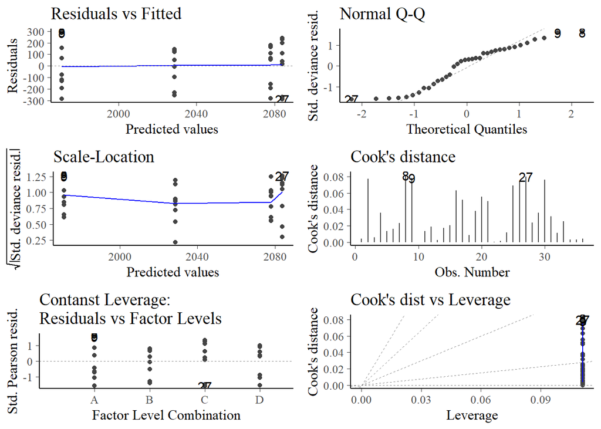

```r
autoplot(ca.glm1, which=1:6)
```

My residuals against the fitted have a pattern. Might not matter, because we know we don’t have normality???

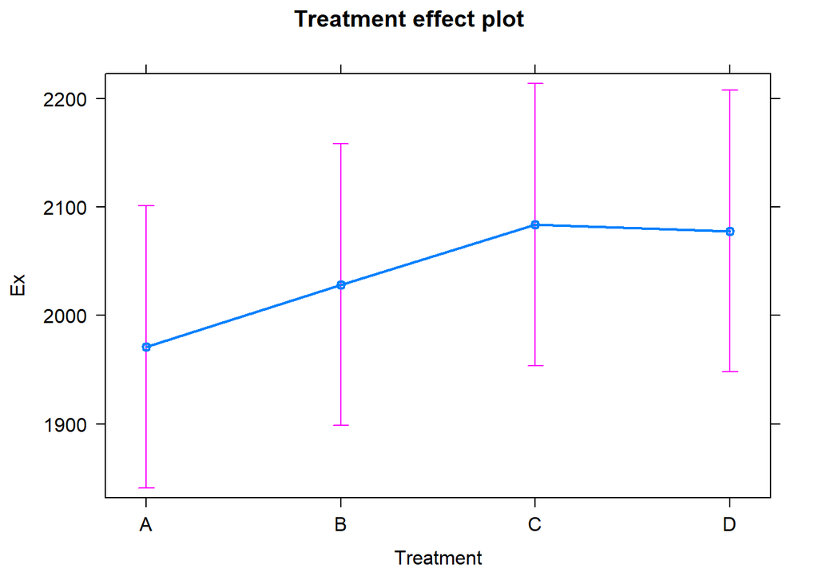

```r
plot(allEffects(ca.glm1))
```

```r
summary(ca.glm1)
```

```
##
## Call:
## glm(formula = Ex ~ Treatment, family = "gaussian", data = ca)
##
## Deviance Residuals:
##     Min       1Q   Median       3Q      Max
## -288.45  -167.15    54.16   141.71   291.99
##
## Coefficients:
##             Estimate Std. Error t value Pr(>|t|)
## (Intercept)  1971.14      63.87  30.862   <2e-16 ***
## TreatmentB     57.45      90.33   0.636    0.529
## TreatmentC    112.68      90.33   1.248    0.221
## TreatmentD    106.86      90.33   1.183    0.246
## ---
## Signif. codes:  0 '***' 0.001 '**' 0.01 '*' 0.05 '.' 0.1 ' ' 1
##
## (Dispersion parameter for gaussian family taken to be 36714.31)
##
##     Null deviance: 1248976  on 35  degrees of freedom
## Residual deviance: 1174858  on 32  degrees of freedom
## AIC: 486.32
##
## Number of Fisher Scoring iterations: 2
```

**Result** : I don’t have significant differences within the treatments… :(

```r
AICc(ca.lm, ca.glm1)
```

```
##         df     AICc
## ca.lm    5 488.3166
## ca.glm1  5 488.3166
```

**Result** : these models are equally bad.

## ANOVA with glm1 model (=gaussian)

```r
anova(ca.glm1)
```

```
## Analysis of Deviance Table
##
## Model: gaussian, link: identity
##
## Response: Ex
##
## Terms added sequentially (first to last)
##
##
##           Df Deviance Resid. Df Resid. Dev
## NULL                         35    1248976
## Treatment  3    74119        32    1174858
```

## Multiple regression model

In order to run a **multiple regression model**, check if my data are linear or non linear:

Are my data linear?

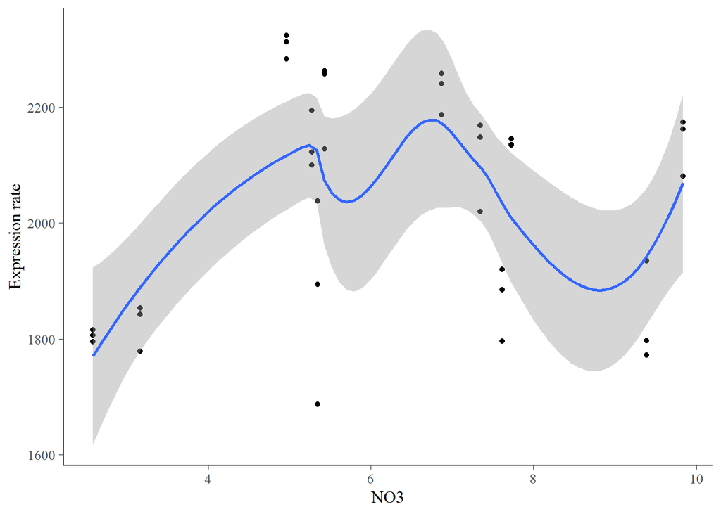

```r
ggplot(ca, aes(y=Ex, x=NO3)) +
        geom_point() +
  geom_smooth() +
       scale_y_continuous(name="Expression rate")
```

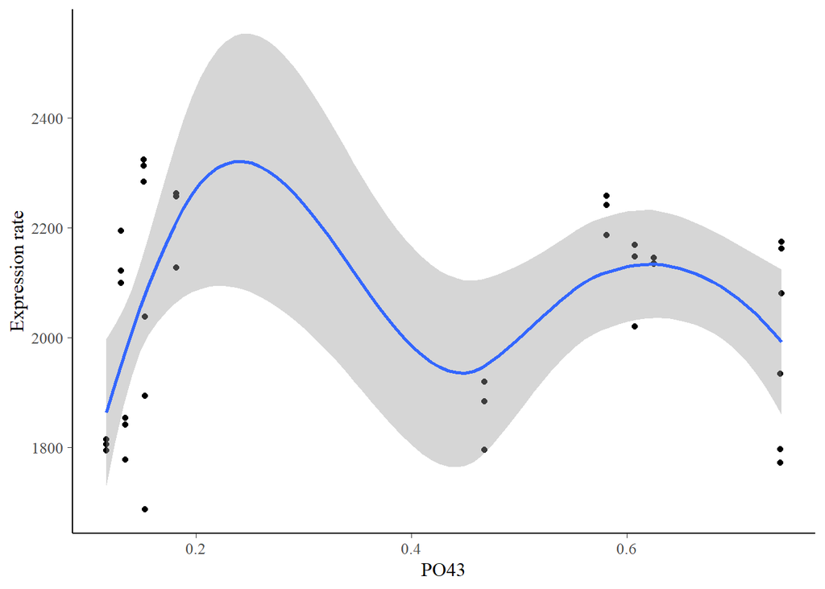

```r
ggplot(ca, aes(y=Ex, x=PO43)) +
        geom_point() +
  geom_smooth() +
       scale_y_continuous(name="Expression rate")
```

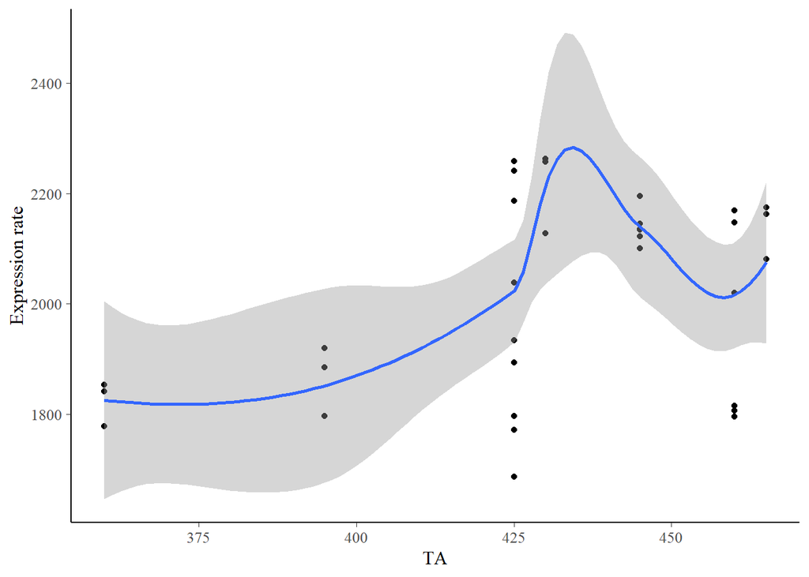

```r
ggplot(ca1, aes(y=Ex, x=TA)) +
        geom_point() +
  geom_smooth() +
       scale_y_continuous(name="Expression rate")
```

**Result** : This is not testing for linearity, isn’t it? Anyhow, my data is not linear. Of course not, because I have different treatments. Since A and C have low nutrient levels, they should have a similar expression rate. Same for B and D. When it comes to TA, then A and B should be similar, same for C and D.

Maybe I need to break my data down into the four treatments A, B, C and D.

A big question here is, if I can use this data and if it’s linear, and does it has to be linear???

Assumptions: (1) all predictors (single impact) should be uncorrelated to another called no multi-co-linearity (centering might make them independent?), (2) predictors should be linear to ??? (3) ???

```r
#scatterplotMatrix(~Ex+Light+Temp+Sal+pH+TA+NO3+PO43, data=ca, diagonal='boxplot')
```

```r
#scatterplotMatrix(~Ex+Light+Sal+pH+log(TA)+NO3+PO43, data=ca, diagonal='boxplot')
```

I will center and scale predictors with the function scale:

```r
ca.lm1<-lm(Ex~scale(Light) + scale(Sal) +scale(pH) + scale(log(TA)) + scale(NO3) + scale(PO43), data=ca)
```

**Result** : Validate the included variables in the lm fit with the variance inflation factor. When the values are less than 3 (or 5), we accept and include. Values were removed or taken because the vif was less or greater than 3 or 5. If vif is to big, (1) you take them out of the model (2) you combine the variables (predictors) by multivariate techniques since they correlate (3) you run the correlated predictors in separated models.

NOTE: An lm is not suitable for my data, I should change this, right?

```r
vif(ca.lm1)
```

```
##   scale(Light)     scale(Sal)      scale(pH) scale(log(TA))     scale(NO3)
##       2.833778       4.211222       3.713985       1.457141      10.309320
##    scale(PO43)
##      15.252834
```

**Result** : Too bad that my nutrients have a vif too high. I could combine them as nutrient model. Light has interestingly a value less than 3. TA as well, which is good.

```r
#autoplot(ca.lm1, which=1:6)
# since we run a gausian model, you don"t need to look at the QQ plot, but look at the residuals vs. fitted plot
# you can't have an overdispersed gausian model
```

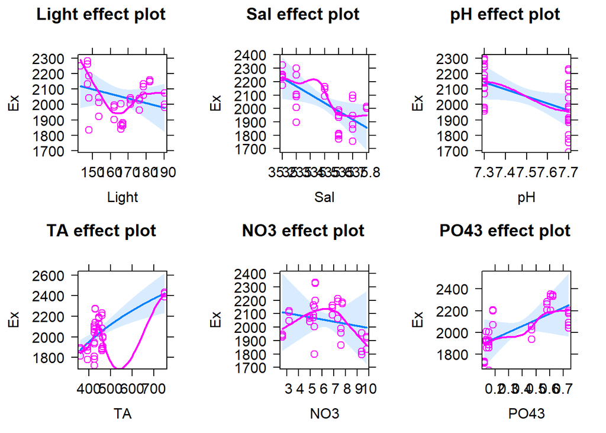

```r
plot(allEffects(ca.lm1, partial.residuals=TRUE))
```

```r
# intercept has meaning since we centered; is predicted expression of enzyme, when all the others are average means
summary(ca.lm1)
```

```
##
## Call:
## lm(formula = Ex ~ scale(Light) + scale(Sal) + scale(pH) + scale(log(TA)) +
##     scale(NO3) + scale(PO43), data = ca)
##
## Residuals:
##      Min       1Q   Median       3Q      Max
## -269.511  -76.304    4.247  106.380  267.989
##
## Coefficients:
##                Estimate Std. Error t value Pr(>|t|)
## (Intercept)     2040.39      24.94  81.825  < 2e-16 ***
## scale(Light)     -43.98      42.57  -1.033  0.31014
## scale(Sal)      -127.66      51.90  -2.460  0.02010 *
## scale(pH)        -92.89      48.74  -1.906  0.06662 .
## scale(log(TA))   128.78      30.53   4.218  0.00022 ***
## scale(NO3)       -34.60      81.20  -0.426  0.67320
## scale(PO43)      141.89      98.77   1.437  0.16155
## ---
## Signif. codes:  0 '***' 0.001 '**' 0.01 '*' 0.05 '.' 0.1 ' ' 1
##
## Residual standard error: 149.6 on 29 degrees of freedom
## Multiple R-squared:  0.4802, Adjusted R-squared:  0.3727
## F-statistic: 4.466 on 6 and 29 DF,  p-value: 0.002565
```

```r
#results is the estimated magnitude of the effect of light when all of the other predictors are out their means; the effect of light standardzed all the means; the means are 0
# look at the probabilities of the t-values and see that (0.00022) TA has a correlation???; TA is important and salinity has an effect (0,02010), because we centered and scaled; the biggest effect is the one with the biggest number of the estimates, which is the phosphate (141.89) and has a positive effect, but no significance; salinity has a strong and neg. effect (-127.66); also TA has a positive effect (128.78)
# drop the least significant until you end up with only significant ways (old function drop); there is a better way to do that, which is ???
```

**Result** : TA and salinity have significant effects.

Check for **confidence intervals**:

```r
# confidence intervals tell you if and how big it is. if 0 is in the interval of the scale, then there is no effect; if there is not a zero, then there is an effect
# this is the same than a p-value, but with significance AND effect
# check the table and numbers from above!
confint(ca.lm1)
```

```
##                     2.5 %      97.5 %
## (Intercept)    1989.39078 2091.390778
## scale(Light)   -131.04779   43.092903
## scale(Sal)     -233.80751  -21.521458
## scale(pH)      -192.56970    6.790033
## scale(log(TA))   66.34236  191.215250
## scale(NO3)     -200.67206  131.476513
## scale(PO43)     -60.11814  343.892351
```

```r
# corrected for small sample sizes (less than around 30 values per predictor), thats why there is the c
AICc(ca.lm1)
```

```
## [1] 476.2943
```

```r
# the value 476.2943 doesn't tell you if it's big or not, good or bad
```

**Result** : It is the same: There is a positive effect of TA and a negative of Sal.

the dredge function aims to have only the parameters that we need to have (parsimonious means the simpliest); a model with the fewest bits it needs to run all the combinations of the predictors to get the best combination; called dredge

```r
# na means no value; it ignores it by default; with this function it takes them into account
# you need to have the same sample size to compare AIC's
ca.lm1 = update(ca.lm1, na.action=na.fail)
# fit all 64 combinations and rank according to the AIC, where best is smallest
dredge(ca.lm1, rank="AICc")
```

```
## Fixed term is "(Intercept)"
```

```
## Global model call: lm(formula = Ex ~ scale(Light) + scale(Sal) + scale(pH) + scale(log(TA)) +
##     scale(NO3) + scale(PO43), data = ca, na.action = na.fail)
## ---
## Model selection table
##    (Int) scl(Lgh) scl(log(TA)) scl(NO3)  scl(pH) scl(PO4) scl(Sal) df
## 59  2040                123.00           -54.060    88.71  -93.070  6
## 51  2040                129.20                      66.43  -62.150  5
## 3   2040                103.60                                      3
## 39  2040                118.20   55.480                    -45.360  5
## 47  2040                109.10   72.690  -49.580           -68.600  6
## 7   2040                105.70   40.940                             4
## 60  2040  -35.200       123.40           -85.370   102.70 -114.900  7
## 19  2040                108.50                      34.54           4
## 35  2040                110.50                             -26.350  4
## 8   2040   25.320       103.80   44.250                             5
```

[output cut: 120 more lines]

```r
# outcome of the dredge is:
# regression coefficient is scl(log(TA))
# the models from 59 to 63 (max) are the best, because the AIC has few units;
# the delta is the difference between the best and the current AIC
# a delta of 4 or more is not a good model
# to get the best value for the predictors, we could average the coefficients, but we don't do that
# instead we take into account the weights, so we average the weights by multiply the first value of the coefficient with the weight and add the folowing one
```

**Result** :

Average the weights

```r
# it is the average of the coefficients in all the models, that have a delta less or as great as 4
ca.av<-model.avg(dredge(ca.lm1, rank="AICc"), subset=delta<=4)
```

```
## Fixed term is "(Intercept)"
## Fixed term is "(Intercept)"
```

```r
summary(ca.av)
```

```
##
## Call:
## model.avg(object = dredge(ca.lm1, rank = "AICc"), subset = delta <=
##     4)
##
## Component model call:
## lm(formula = Ex ~ <18 unique rhs>, data = ca, na.action = na.fail)
##
## Component models:
##       df  logLik   AICc delta weight
## 2456   6 -228.14 471.17  0.00   0.15
## 256    5 -229.86 471.72  0.55   0.11
## 2      3 -232.82 472.38  1.21   0.08
## 236    5 -230.19 472.39  1.22   0.08
## 2346   6 -228.75 472.40  1.23   0.08
## 23     4 -231.57 472.42  1.26   0.08
## 12456  7 -227.59 473.19  2.02   0.06
## 25     4 -231.95 473.19  2.03   0.05
## 26     4 -232.34 473.97  2.81   0.04
## 123    5 -231.08 474.15  2.98   0.03
## 1256   6 -229.65 474.19  3.03   0.03
## 23456  7 -228.13 474.26  3.09   0.03
## 12     4 -232.54 474.37  3.20   0.03
## 1236   6 -229.75 474.40  3.23   0.03
## 2356   6 -229.86 474.62  3.45   0.03
## 234    5 -231.34 474.68  3.51   0.03
## 24     4 -232.77 474.82  3.66   0.02
## 235    5 -231.51 475.03  3.86   0.02
##
## Term codes:
##   scale(Light) scale(log(TA))     scale(NO3)      scale(pH)    scale(PO43)
##              1              2              3              4              5
##     scale(Sal)
##              6
##
## Model-averaged coefficients:
## (full average)
##                 Estimate Std. Error Adjusted SE z value Pr(>|z|)
## (Intercept)    2040.3908    25.6780     26.6892  76.450  < 2e-16 ***
## scale(log(TA))  115.1340    29.2648     30.2935   3.801 0.000144 ***
```

[output cut: 10 more lines]

```
## scale(pH)       -52.249     38.212      39.383   1.327 0.184611
## scale(PO43)      70.699     50.870      52.339   1.351 0.176764
## scale(Sal)      -71.043     40.751      41.852   1.697 0.089608 .
## scale(NO3)       47.671     44.937      46.376   1.028 0.303991
## scale(Light)      4.039     39.740      40.675   0.099 0.920891
## ---
## Signif. codes:  0 '***' 0.001 '**' 0.01 '*' 0.05 '.' 0.1 ' ' 1
##
## Relative variable importance:
##                      scale(log(TA)) scale(Sal) scale(PO43) scale(NO3)
## Importance:          1.00           0.64       0.49        0.42
## N containing models:   18             10          8           9
##                      scale(pH) scale(Light)
## Importance:          0.37      0.18
## N containing models:    6         5
```

```r
# outcome: the relative importance
# 18 models out of ? have 100% importance of TA included; salinity with 64% is important, but probably not phosphate with 49%
# dredge is not recommended to do!
```

```r
anova(ca.lm1)
```

```
## Analysis of Variance Table
##
## Response: Ex
##                Df Sum Sq Mean Sq F value    Pr(>F)
## scale(Light)    1  26793   26793  1.1969 0.2829420
## scale(Sal)      1    607     607  0.0271 0.8703710
## scale(pH)       1  40755   40755  1.8207 0.1876765
## scale(log(TA))  1 343902  343902 15.3630 0.0004975 ***
## scale(NO3)      1 141556  141556  6.3237 0.0177130 *
## scale(PO43)     1  46196   46196  2.0637 0.1615457
## Residuals      29 649167   22385
## ---
## Signif. codes:  0 '***' 0.001 '**' 0.01 '*' 0.05 '.' 0.1 ' ' 1
```

***Result** : This has significant p-values for TA and NO3!

Create **candidate models** with factors you think are important

You can have a different approach instead of mathematically provide a sensitive model, you can better create your own model, such as a model that includes the factors that you think they are important and have influence; that way you already have a to give a logical reason why these factors are relevant. Hence, ecological vs. statistical model!!! Check if the model you created actually to provide values that tells you this model shows that the predictors are indeed important. The update function just takes what has already been done and add what you wish to add; here only chosen scaled predictors

```r
ca.lm2<-update(ca.lm,  .~scale(NO3) + scale(PO43)) # nutrient model
ca.lm3<-update(ca.lm,  .~scale(Light) + scale(TA)) # bleaching model
ca.lm4<-update(ca.lm,  .~scale(TA)) # OA model
ca.lm5<-update(ca.lm,  .~scale(NO3) + scale(PO43) + scale(TA)) # treat model
ca.lm6<-update(ca.lm,  .~scale(TA) + scale(Sal)) # sal model
# no predictors to kinda have a control
ca.null<-update(ca.lm, .~1) # no-predictor model
```

Check, which one is the best fit with comparing the **AIC**:

```r
AICc(ca.lm2, ca.lm3, ca.lm4, ca.lm5, ca.lm6, ca.null)
```

```
##         df     AICc
## ca.lm2   4 485.3368
## ca.lm3   4 475.7139
## ca.lm4   3 473.6520
## ca.lm5   5 475.8887
## ca.lm6   4 475.5117
## ca.null  2 482.8826
```

```r
# result: high AIC is bad, so lm1 is worse than the no-predictor model, habitat model is important; you compare them also to the global model, which is loyn.lm
```

**Result** : lm4 my OA model has the best AIC. Since the lm2 is worse than the control, I think they don’t make sense to use even though it has a higher df.

I AM NOT SURE, IF I CAN CONTINUE WITH LM IF THAT MIGHT NOT BE A GOOD FIT!!!

```r
summary(ca.lm4)
```

```
##
## Call:
## lm(formula = Ex ~ scale(TA), data = ca)
##
## Residuals:
##     Min      1Q  Median      3Q     Max
## -319.33 -100.25    3.98  116.26  252.10
##
## Coefficients:
##             Estimate Std. Error t value Pr(>|t|)
## (Intercept)  2040.39      27.18  75.058  < 2e-16 ***
## scale(TA)      99.21      27.57   3.598  0.00101 **
## ---
## Signif. codes:  0 '***' 0.001 '**' 0.01 '*' 0.05 '.' 0.1 ' ' 1
##
## Residual standard error: 163.1 on 34 degrees of freedom
## Multiple R-squared:  0.2758, Adjusted R-squared:  0.2545
## F-statistic: 12.95 on 1 and 34 DF,  p-value: 0.001006
```

**Result** : most important predictor is TA due to the value of 99.21. 34 df gives the model some power. But I can explain only 27.58%, which can be seen in the r square of 0.2758. That make sense considering that my TA is only high for content 7.

Let’s check on the other models (3, 5 and 6) anyhow:

```r
summary(ca.lm3)
```

```
##
## Call:
## lm(formula = Ex ~ scale(Light) + scale(TA), data = ca)
##
## Residuals:
##     Min      1Q  Median      3Q     Max
## -297.90 -102.86   18.04  127.98  279.05
##
## Coefficients:
##              Estimate Std. Error t value Pr(>|t|)
## (Intercept)   2040.39      27.41  74.439  < 2e-16 ***
## scale(Light)    18.55      27.92   0.664  0.51105
## scale(TA)       97.47      27.92   3.491  0.00139 **
## ---
## Signif. codes:  0 '***' 0.001 '**' 0.01 '*' 0.05 '.' 0.1 ' ' 1
##
## Residual standard error: 164.5 on 33 degrees of freedom
## Multiple R-squared:  0.2854, Adjusted R-squared:  0.2421
## F-statistic: 6.589 on 2 and 33 DF,  p-value: 0.003912
```

**Result** : is similar to lm4

```r
summary(ca.lm5)
```

```
##
## Call:
## lm(formula = Ex ~ scale(NO3) + scale(PO43) + scale(TA), data = ca)
##
## Residuals:
##     Min      1Q  Median      3Q     Max
## -309.76 -107.45  -11.29   97.68  260.64
##
## Coefficients:
##             Estimate Std. Error t value Pr(>|t|)
## (Intercept)  2040.39      26.87  75.929   <2e-16 ***
## scale(NO3)     63.54      68.43   0.928   0.3601
## scale(PO43)   -20.46      69.32  -0.295   0.7697
## scale(TA)     101.25      28.24   3.585   0.0011 **
## ---
## Signif. codes:  0 '***' 0.001 '**' 0.01 '*' 0.05 '.' 0.1 ' ' 1
##
## Residual standard error: 161.2 on 32 degrees of freedom
## Multiple R-squared:  0.334,  Adjusted R-squared:  0.2715
## F-statistic: 5.348 on 3 and 32 DF,  p-value: 0.004227
```

**Result** : is similar to lm4, even though I can explain 33.4%.

```r
summary(ca.lm6)
```

```
##
## Call:
## lm(formula = Ex ~ scale(TA) + scale(Sal), data = ca)
##
## Residuals:
##     Min      1Q  Median      3Q     Max
## -337.62 -123.98    5.89  137.93  255.77
##
## Coefficients:
##             Estimate Std. Error t value Pr(>|t|)
## (Intercept)  2040.39      27.33  74.649  < 2e-16 ***
## scale(TA)     104.60      28.54   3.665 0.000862 ***
## scale(Sal)    -22.65      28.54  -0.794 0.433103
## ---
## Signif. codes:  0 '***' 0.001 '**' 0.01 '*' 0.05 '.' 0.1 ' ' 1
##
## Residual standard error: 164 on 33 degrees of freedom
## Multiple R-squared:  0.2894, Adjusted R-squared:  0.2463
## F-statistic: 6.719 on 2 and 33 DF,  p-value: 0.003566
```

**Result** : is similar to lm4.

Check on the conf int.

```r
confint(ca.lm4)
```

```
##                2.5 %    97.5 %
## (Intercept) 1985.146 2095.6354
## scale(TA)     43.179  155.2356
```

How do I interprete this?

I am 95% confident that the true value lies between 1985.17 and 2095.64.

### Visualize the results of the lm:

```r
ca.grid = with(ca, list(TA=seq(min(TA), max(TA), len=100)))
newdata=emmeans(ca.lm4,~TA, at=ca.grid) %>%
        as.data.frame
head(newdata)
```

```
##         TA   emmean       SE df lower.CL upper.CL
## 1 360.0000 1938.022 39.34818 34 1858.057 2017.987
## 2 363.9394 1942.176 38.52185 34 1863.890 2020.461
## 3 367.8788 1946.330 37.71275 34 1869.688 2022.971
## 4 371.8182 1950.483 36.92201 34 1875.449 2025.518
## 5 375.7576 1954.637 36.15084 34 1881.170 2028.105
## 6 379.6970 1958.791 35.40053 34 1886.849 2030.734
```

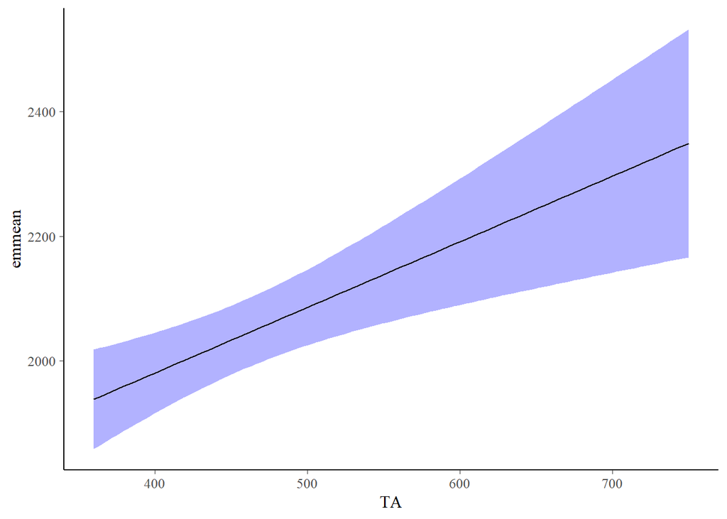

```r
ggplot(newdata, aes(y=emmean, x=TA)) +
        geom_ribbon(aes(ymin=lower.CL, ymax=upper.CL), fill='blue', alpha=0.3) +
        geom_line()
```

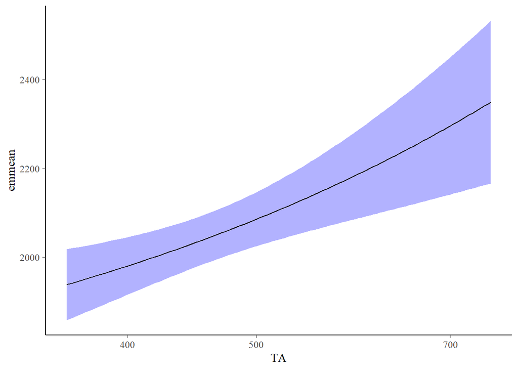

```r
ggplot(newdata, aes(y=emmean, x=TA)) +
        geom_ribbon(aes(ymin=lower.CL, ymax=upper.CL), fill='blue', alpha=0.3) +
        geom_line() +
        scale_x_log10()
```

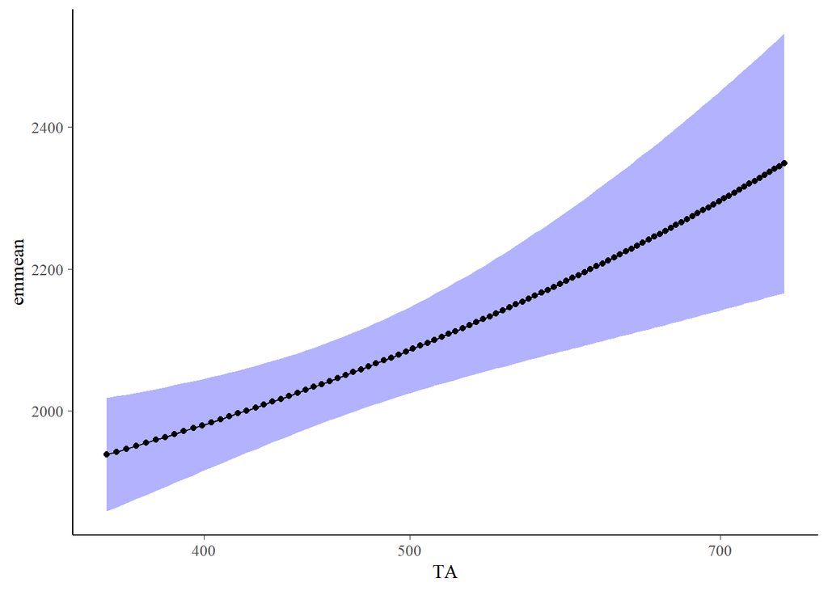

```r
ggplot(newdata, aes(y=emmean, x=TA)) +
        geom_ribbon(aes(ymin=lower.CL, ymax=upper.CL), fill='blue', alpha=0.3) +
        geom_line() +
        scale_x_log10() +
        geom_point()
```

```r
# to get the partial observation of TA values acutally observed and taken
#partial.obs=emmeans(ca.lm4, ~TA, at=list(TA=ca$TA)) %>%
#        as.data.frame %>%
#        mutate(emmean=emmean+resid(ca.lm4))
# this is the point when you calculate the true position of the dots by taking the residual adding them to the regression line;  because the raw data is not standardized, we cannot include them into the plot
# to display the difference between the calculated and the raw data, see this
#ggplot(newdata, aes(y=emmean, x=TA)) +
#        geom_ribbon(aes(ymin=lower.CL, ymax=upper.CL), fill='blue', alpha=0.3) +
#        geom_line() +
#        scale_x_log10() +
#        geom_point(data=partial.obs) +
#        geom_point(data=ca, aes(y=Ex), color="red")
```

**Result** : The outcome of the multiple regression analysis is that TA is the main driver in my expression rate of the CA. The nutrients don’t seem to influence much. If so, it would be the salinity.

## Multiple non-linear regression model (nls)

Probably I need to fit a **multiple non-linear regression model** (nls), because my data are not linear. How?

```r
#ca.nls<-nls(Ex~scale(Light) + scale(Sal) +scale(pH) + scale(log(TA)) + scale(NO3) + scale(PO43), data=ca)
```

## Which model? lmer or glmer? Poisson

With which model should I fit my data? According to this website, maybe I can try an lme or better glmer. Let me compare with the R course from Murray how to do that.

https://www.zoology.ubc.ca/~schluter/R/fit-model/

Which family should I use to fit my **glmer**? binomial doesn’t make sense, since I don’t have yes or no data. gaussian neither, since my data is not linear. Gamma? Poisson… non integer problem….

### lme vs. lmer vs. glmmtmb

**lme** : We will start by fitting the linear mixed effects model.

The hierarchical random effects structure is defined by the random= parameter. In this case, random=~1|block indicates that blocks are random effects and that the intercept should be allowed to vary per block.

```r
ca.lme1<-lme(Ex~ppm, random = ~1|nut, data=ca, method="REML")
```

```r
# allow the effect to be different for each nutrient
ca.lme2<-lme(Ex~ppm, random=~ppm|nut, data=ca, method='REML')
```

**lmer**: In contrast to lme(), the lmer() routine does not specify separate fixed and random formulae. Instead the random effects are indicated as something like (1|block) for random intercept and (x|block) for random intercept/slope.

```r
ca.lmer<- lmer(Ex~ppm + (1|nut), data=ca, REML=TRUE)
```

```
## boundary (singular) fit: see ?isSingular
```

**glmmTMB** :

```r
ca.glmmTMB<- glmmTMB(Ex~ppm + (1|nut), data=ca)
```

Compare all lme models:

```r
AICc(ca.lm, ca.lm4, ca.lme1, ca.lme2, ca.lmer, ca.glmmTMB)
```

```
##            df     AICc
## ca.lm       5 488.3166
## ca.lm4      3 473.6520
## ca.lme1     4 467.3005
## ca.lme2     6 472.9068
## ca.lmer     4 467.3005
## ca.glmmTMB  4 486.0638
```

**Result** : The lowest AIC has the lme1/lmer, but the highest df the lme2. Let’s continue with lme1

Compare all fitted models:

```r
#AICc(ca.lm, ca.lm4, ca.glm, ca.glm1, ca.glm2, ca.glm3, ca.glmer, ca.lme1, ca.lme2, ca.lmer, ca.glmmTMB, ca1.gp.gam)
```

```r
# there is no evidence one is better than the other, since the p-value is higher than 0.05
anova(ca.lme1, ca.lme2)
```

```
##         Model df      AIC      BIC    logLik   Test      L.Ratio p-value
## ca.lme1     1  4 466.0102 472.1157 -229.0051
## ca.lme2     2  6 470.0102 479.1684 -229.0051 1 vs 2 3.950163e-09       1
```

### Validate lme1

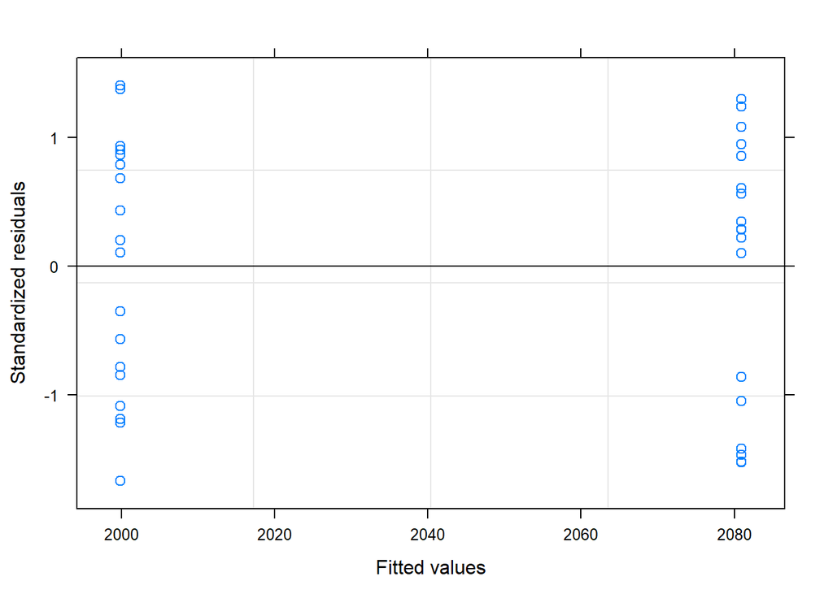

```r
# autoplot doesn't work with this lme, so we use the one that comes with lme
plot(ca.lme1)
```

**Result** : We have a pattern…. Because I have a bimodal distribution?

```r
summary(ca.lme1)
```

```
## Linear mixed-effects model fit by REML
##  Data: ca
##        AIC      BIC    logLik
##   466.0102 472.1157 -229.0051
##
## Random effects:
##  Formula: ~1 | nut
##         (Intercept) Residual
## StdDev: 0.009304843 187.0722
##
## Fixed effects: Ex ~ ppm
##                Value Std.Error DF  t-value p-value
## (Intercept) 2080.912  44.09335 33 47.19334  0.0000
## ppmlow       -81.043  62.35741 33 -1.29965  0.2027
##  Correlation:
##        (Intr)
## ppmlow -0.707
##
## Standardized Within-Group Residuals:
##        Min         Q1        Med         Q3        Max
## -1.6712172 -0.9092474  0.2523133  0.8591216  1.4072681
##
## Number of Observations: 36
## Number of Groups: 2
```

**Result** : My nutirnets are not random effects!?!

### Validate glmer

```r
# autoplot doesn't work with this lme, so we use the one that comes with lme
#plot(ca.glmer)
```

## Polynomial?

fit a polynomial??? (Split plot design by murray)

```r
#ca.glmer=lmer(Ex~ppm+(1|nut),data=ca)
```

**Result** :

```r
#summary(ca.glmer)
```

```r
# fitted residuals against standardised residuals
#plot(ca.glmer)
```

```r
#ca.aug=augment(ca.glmer)
#ggplot(ca.aug, aes(y=.wtres, x=ppm)) +
  geom_boxplot()
```

[output not shown]

```r
#ggplot(ca.aug, aes(y=.wtres, x=nut)) +
#  geom_boxplot()
```

```r
#ca.resid=sum(resid(ca.glmer, type='pearson')^2)
#1-pchisq(ca.resid, df=df.residual(ca.glmer))

# Maximum likelihood doesn't do anything with residuals, but with likelihood (deviance)
# the outlier has an impact on the residuals, that's why there is a lack of fit
#1-pchisq(deviance(ca.glmer), df.residual(ca.glmer))
```

```r
#coefficients(ca.glmer)
```

```r
#plot(allEffects(ca.glmer), type='response')
```

## Mixed effects model (GLMM) / Split-Plot Design

Generalized linear mixed effects models; using REML (Maximum Likelihood); lmer/nlme for non linear

Use ca1, which doesn’t contain the outlier!

I would like to do the planned comparison, if I just knew which distribution to fit. Log transform my data to avoid normality assumption (log(TA))?

```r
# make sure which is the order of your levels
# orthogonal or independent
levels(ca$Treatment)
```

```
## [1] "A" "B" "C" "D"
```

```r
# check your table in your notebook to know, which comparisons you aim to do
# this is how your create your matrix
contr.Treatment=cbind(control=c(1, -1/3, -1/3, -1/3),
                     NoNut_vs_Nut=c(-1/2, 1/2, -1/2, 1/2),
                      NoCO2_vs_CO2=c(-1/2, -1/2, 1/2, 1/2),
                     control_vs_both=c(-1, 0, 0, 1))
contr.Treatment
```

```
##         control NoNut_vs_Nut NoCO2_vs_CO2 control_vs_both
## [1,]  1.0000000         -0.5         -0.5              -1
## [2,] -0.3333333          0.5         -0.5               0
## [3,] -0.3333333         -0.5          0.5               0
## [4,] -0.3333333          0.5          0.5               1
```

```r
# it's easier if you round your values, so it looks better
# we round to 1 decimal
round(crossprod(contr.Treatment),1)
```

```
##                 control NoNut_vs_Nut NoCO2_vs_CO2 control_vs_both
## control             1.3         -0.7         -0.7            -1.3
## NoNut_vs_Nut       -0.7          1.0          0.0             1.0
## NoCO2_vs_CO2       -0.7          0.0          1.0             1.0
## control_vs_both    -1.3          1.0          1.0             2.0
```

```r
#that's how it may look if you don't round: crossprod(contr.Treat)
```

Fit the correct model here, which is not glmer, since this had a poisson distribution, which is why I get the non integer problem again!!! Not true: It had gaussian!

```r
#emmeans(ca.glmer, ~Ex, contr=list(contr.Ex), type='response')
```

```r
#MuMIn::r.squaredGLMM(ca.glmer)
```

check for the **offset** function!

An offset term is used for a covariate with *known* slope. An offset is a term to be added to a linear predictor, such as in a generalised linear model, with known coefficient 1 rather than an estimated coefficient.

#### Data Transformation

Normalize your data by log transformation before using. Guess it’s about TA.

Transforming to a uniform distribution or an arbitrary distribution with the rank transformation:

# collect the values together, and assign them to a variable called y

c(32.2, 10.0, 135.2, 145.3, 145.301) -> y

```r
y<-ca$Ex
y
```

```
##  [1] 2037.972 1687.231 1894.013 1777.996 1853.523 1841.867 2127.579
##  [8] 2263.130 2256.973 2020.006 2147.816 2168.967 2080.946 2162.084
## [15] 2174.321 1772.114 1796.851 1934.258 2283.357 2324.306 2312.887
## [22] 2100.075 2122.251 2194.706 1815.089 1806.386 1795.381 1919.512
## [29] 1884.733 1796.367 2258.665 2186.725 2241.131 2135.410 2133.976
## [36] 2145.464
```

rank( y ) # give their rank

```r
rEx<-rank(y)
rEx
```

```
##  [1] 16  1 12  3 10  9 20 33 31 15 24 26 17 25 27  2  6 14 34 36 35 18 19
## [24] 29  8  7  4 13 11  5 32 28 30 22 21 23
```